# Create and Analyse a Dataset

To begin we’ll load `owidR` using the `library()` function. We’ll also load `dplyr`, `ggplot2`, `plm` as well as `texreg` which we’ll be using to do the analysis.

```r
library(owidR)
library(dplyr)
library(ggplot2)
library(plm)
library(texreg)
```

```r
owid_search("internet")
```

```r
internet <- owid("share-of-individuals-using-the-internet", rename = "internet_use")
internet
```

```
#> # A tibble: 6,660 × 4
#>    entity      code   year internet_use
#>  * <chr>       <chr> <int>        <dbl>
#>  1 Afghanistan AFG    1990      0
#>  2 Afghanistan AFG    1991      0
#>  3 Afghanistan AFG    1992      0
#>  4 Afghanistan AFG    1993      0
#>  5 Afghanistan AFG    1994      0
#>  6 Afghanistan AFG    1995      0
#>  7 Afghanistan AFG    2001      0.00472
#>  8 Afghanistan AFG    2002      0.00456
#>  9 Afghanistan AFG    2003      0.0879
#> 10 Afghanistan AFG    2004      0.106
#> # … with 6,650 more rows
```

We can find information about the source of data by using `owid_source()`, with the owid dataset object as the argument. This gives us the original publisher of the data as well as a link to the data. For some datasets additional information about how the variables is calculated is also provided. Using `view_chart()` takes you to the [Our World in Data](https://ourworldindata.org) webpage for that dataset, where there is also additional information and a pretty graph.

```r
owid_source(internet)
```

```
#> Dataset Name: International Telecommunication Union (via World Bank)
#>
#> Published By: World Development Indicators - World Bank (2022.05.26)
#>
#> Link: https://datacatalog.worldbank.org/search/dataset/0037712/World-Development-Indicators
```

```r
view_chart(internet)
```

To create simple plots to see how internet use has changed over time simply use `owid_plot()`, filtering to give the World total. Given that this function is a wrapper around `ggplot2` you can use normal `ggplot2` functions to further manipulate the graph. I’m going to add a title using `labs()` and change the y axis scale so that it starts from 0 (this makes the graph clearer to interpret given that the value is a percentage, otherwise small variations can appear large).

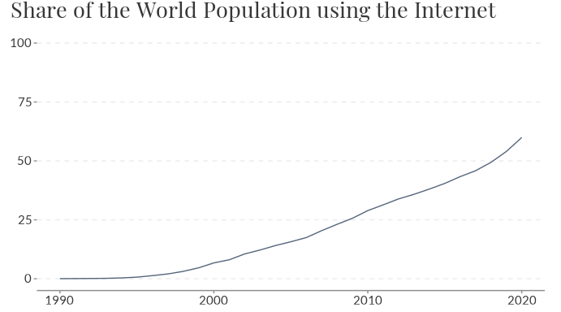

```r
owid_plot(internet, filter = "World") +
  labs(title = "Share of the World Population using the Internet") +
  scale_y_continuous(limits = c(0, 100))
```

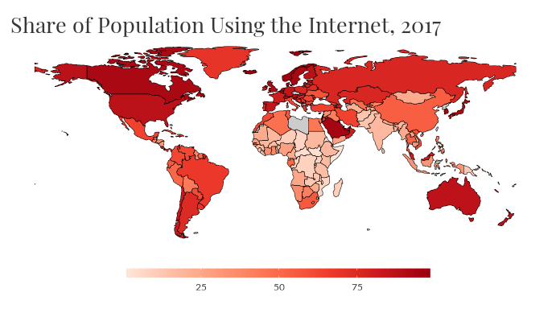

```r
owid_map(internet, year = 2017) +
  labs(title = "Share of Population Using the Internet, 2017")
```

It’s also possible to compare countries level of internet use across time, again using `owid_plot()`. By using the argument `summarise = FALSE`, `owid_plot()` will show individual countries instead of aggregating them into the total. You can then use the `filter` argument to select which countries you want to be displayed.

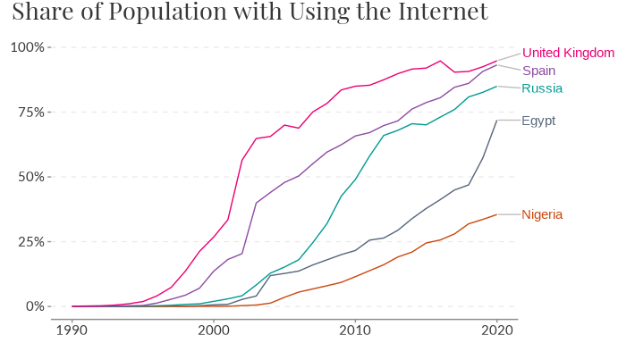

```r
owid_plot(internet, summarise = FALSE, filter = c("United Kingdom", "Spain", "Russia", "Egypt", "Nigeria")) +
  labs(title = "Share of Population with Using the Internet") +
  scale_y_continuous(limits = c(0, 100), labels = scales::label_number(suffix = "%")) # The labels argument allows you to make it clear that the value is a percentage
```

Now let’s get data on democracy, first searching for a data source and then importing it using `owid()`. Using that data we’ll do some similar exploration to what we did with internet use data.

```r
owid_search("democrac")
```

```r
democracy <- owid("electoral-democracy", rename = c("electoral_democracy", "vdem_high", "vdem_low"))
democracy
```

```
#> # A tibble: 32,518 × 6
#>    entity      code   year electoral_democracy vdem_high vdem_low
#>  * <chr>       <chr> <int>               <dbl>     <dbl>    <dbl>
#>  1 Afghanistan AFG    1789               0.019     0.024     0.01
#>  2 Afghanistan AFG    1790               0.019     0.024     0.01
#>  3 Afghanistan AFG    1791               0.019     0.024     0.01
#>  4 Afghanistan AFG    1792               0.019     0.024     0.01
#>  5 Afghanistan AFG    1793               0.019     0.024     0.01
#>  6 Afghanistan AFG    1794               0.019     0.024     0.01
#>  7 Afghanistan AFG    1795               0.019     0.024     0.01
#>  8 Afghanistan AFG    1796               0.019     0.024     0.01
#>  9 Afghanistan AFG    1797               0.019     0.024     0.01
#> 10 Afghanistan AFG    1798               0.019     0.024     0.01
#> # … with 32,508 more rows
```

```r
owid_source(democracy)
```

[output not shown]

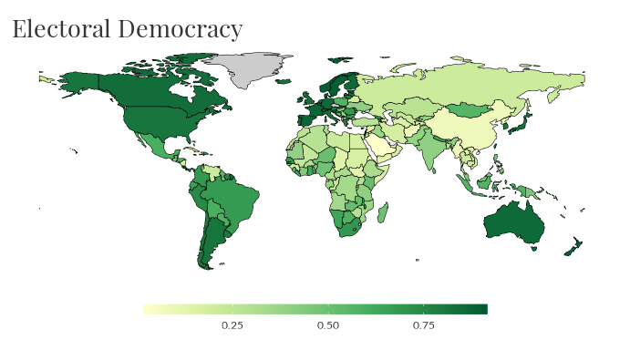

```r
owid_map(democracy, palette = "YlGn") +
  labs(title = "Electoral Democracy")
```

So we’ve done some nice exploratory analysis and produced some pretty graphs, but now let’s get into some more in depth analysis. We’ll use a fixed effect (FE) regression analysis to estimate the average effect that an increase in internet use has on democracy within a country. If you aren’t familiar with FE regression [this article](https://towardsdatascience.com/fixed-effect-regression-simply-explained-ab690bd885cf) explain its purpose well and [this chapter](https://www.econometrics-with-r.org/10-3-fixed-effects-regression.html) from Introduction to Econometrics with R shows how to implement it in R. To estimate the effect of internet use we’re going to use a within-unit fixed effects model.

This model will require us to adjust for confounding factors, so we’ll need some extra data. I’m going to use data on variables that I think might be confounding the relationship between internet use and democracy. These are: GDP per Capita, Government Expenditure, Age Dependency and Unemployment. There are almost certainly more confounding factors so feel free to use `owid_search()` to find data on other variables you think might be confounders and add them to the analysis.

```r
gdp <- owid("gdp-per-capita-worldbank", rename = "gdp")

gov_exp <- owid("total-gov-expenditure-gdp-wdi", rename = "gov_exp")

age_dep <- owid("age-dependency-ratio-of-working-age-population", rename = "age_dep")

unemployment <- owid("unemployment-rate", rename = "unemp")
```

In order to create an FE model, all these separate dataframes now need to combined into one. To do this I’m going to use the `left_join()` function from `dplyr` and create a new dataframe called `data` that combines all the other dataframes.

```r
data <- internet %>%
  left_join(democracy) %>%
  left_join(gdp) %>%
  left_join(gov_exp) %>%
  left_join(age_dep) %>%
  left_join(unemployment)
```

Now that we have a combined dataset we can get to the analysis. First, let’s use `ggplot2` create a graph to see the correlation between internet access and democracy in 2015.

```
#> Warning: Removed 43 rows containing non-finite values (`stat_smooth()`).
#> Warning: Removed 43 rows containing missing values (`geom_point()`).
```

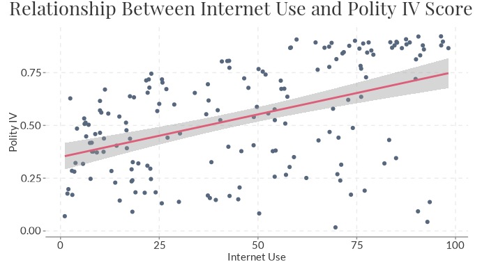

```r
data %>%
  filter(year == 2015) %>%
  ggplot(aes(internet_use, electoral_democracy)) +
  geom_point(colour = "#57677D") +
  geom_smooth(method = "lm", colour = "#DC5E78") +
  labs(title = "Relationship Between Internet Use and Polity IV Score", x = "Internet Use", y = "Polity IV") +
  theme_owid()
```

There appears to be some relationship but this could easily be explained by countries with higher development also being more democratic and not actually the result of internet access. That’s why we control for GDP and the other confounders. Next, we’ll create two models, one with just internet use and democracy, and the other with the confounders added.

```r
fe_model <- plm(electoral_democracy ~ internet_use, data,
                effect = c("individual"), index = "entity")

fe_model_2 <- plm(electoral_democracy ~ internet_use + gdp + gov_exp + age_dep + unemp, data,
                  effect = c("individual"), index = "entity")

htmlreg(list(fe_model, fe_model_2))
```

Statistical models

|  | Model 1 | Model 2 |
| --- | --- | --- |
| internet_use | 0.00*** | 0.00 |
|  | (0.00) | (0.00) |
| gdp |  | -0.00 |
|  |  | (0.00) |
| gov_exp |  | 0.00** |
|  |  | (0.00) |
| age_dep |  | -0.00*** |
|  |  | (0.00) |
| unemp |  | 0.00*** |
|  |  | (0.00) |
| R<sup>2</sup> | 0.02 | 0.07 |
| Adj. R<sup>2</sup> | -0.01 | 0.01 |
| Num. obs. | 5313 | 2670 |

***p < 0.001; **p < 0.01; *p < 0.05

You can see that internet use has a significant positive effect in the first model, but once the confounders are added the effect is insignificant. This means that our model provides no evidence that internet use has an effect on democracy. However, feel free to play around with this data yourself and see if you get a different result when other variables are used.